# Receiving news - Mixed Linear models

```
By Valentin Guigon
June 2023
```

# I. Mixed Linear Models

## A. MLM of success: Better performances for true news

We test models of success as explained by the veracity of news:

|  | Success |  |  | Success |  |  | Success |  |  |
| --- | --- | --- | --- | --- | --- | --- | --- | --- | --- |
| Predictors | Odds Ratios | CI | p | Odds Ratios | CI | p | Odds Ratios | CI | p |
| (Intercept) | 0.64 | 0.61 – 0.68 | **<0.001** | 0.54 | 0.50 – 0.59 | **<0.001** | 0.43 | 0.27 – 0.67 | **<0.001** |
| Veracity: False | *Reference* |  |  | *Reference* |  |  | *Reference* |  |  |
| Veracity: True | 2.77 | 2.58 – 2.98 | **<0.001** | 4.16 | 3.65 – 4.73 | **<0.001** | 4.35 | 3.78 – 5.00 | **<0.001** |
| Theme: Ecology | *Reference* |  |  | *Reference* |  |  | *Reference* |  |  |
| Theme: Social Justice |  |  |  | 1.24 | 1.09 – 1.41 | **0.001** | 1.24 | 1.08 – 1.42 | **0.002** |
| Theme: Democracy |  |  |  | 1.33 | 1.17 – 1.51 | **<0.001** | 1.37 | 1.19 – 1.56 | **<0.001** |
| VeracityTrue:ThemeSocial Justice |  |  |  | 0.74 | 0.62 – 0.89 | **0.001** | 0.73 | 0.60 – 0.89 | **0.002** |
| VeracityTrue:ThemeDemocracy |  |  |  | 0.41 | 0.35 – 0.50 | **<0.001** | 0.38 | 0.31 – 0.46 | **<0.001** |
| Judgment: False | *Reference* |  |  | *Reference* |  |  | *Reference* |  |  |
| Judgment: True |  |  |  |  |  |  | 0.88 | 0.81 – 0.96 | **0.003** |
| Confidence |  |  |  |  |  |  | 1.03 | 0.99 – 1.08 | 0.128 |
| Age |  |  |  |  |  |  | 0.99 | 0.94 – 1.04 | 0.662 |
| Sex: Female | *Reference* |  |  | *Reference* |  |  | *Reference* |  |  |
| Sex: Male |  |  |  |  |  |  | 1.06 | 0.97 – 1.15 | 0.177 |
| Epistemic_curiosity |  |  |  |  |  |  | 1.02 | 0.98 – 1.06 | 0.420 |
| Education: Brevet | *Reference* |  |  | *Reference* |  |  | *Reference* |  |  |
| Education: Bac |  |  |  |  |  |  | 1.32 | 0.85 – 2.04 | 0.213 |
| Education: Licence |  |  |  |  |  |  | 1.24 | 0.77 – 1.99 | 0.376 |
| Education: Master |  |  |  |  |  |  | 1.30 | 0.83 – 2.03 | 0.249 |
| Random Effects |  |  |  |  |  |  |  |  |  |
| σ<sup>2</sup> | 3.29 |  |  | 3.29 |  |  | 3.29 |  |  |
| τ<sub>00</sub> | 0.00 <sub>Subject</sub> |  |  | 0.00 <sub>Subject</sub> |  |  | 0.01 <sub>Subject</sub> |  |  |
| τ<sub>11</sub> |  |  |  |  |  |  | 0.01 <sub>Subject.JudgmentTrue</sub> |  |  |
|  |  |  |  |  |  |  | 0.02 <sub>Subject.Confidence</sub> |  |  |
| ρ<sub>01</sub> |  |  |  |  |  |  | -0.98 |  |  |
|  |  |  |  |  |  |  | 0.68 |  |  |
| N | 258 <sub>Subject</sub> |  |  | 258 <sub>Subject</sub> |  |  | 228 <sub>Subject</sub> |  |  |
| Observations | 12384 |  |  | 12384 |  |  | 10944 |  |  |
| Marginal R<sup>2</sup> / Conditional R<sup>2</sup> | 0.073 / NA |  |  | 0.086 / NA |  |  | 0.090 / NA |  |  |

We compute estimated marginal means (emmeans) of success as explained by the model of veracity interacting with theme, controlled as follow:

```
## Success ~ Veracity * Theme + Confidence + Judgment + Age + Sex +
##     Education + Epistemic_curiosity + (1 + Judgment + Confidence |
##     Subject)
```

We run type III anova to test for the interaction effect plus main effects

| Variables | Chisq | Df | Pr(>Chisq) |
| --- | --- | --- | --- |
| (Intercept) | 13.55 | 1 | <.001 *** |
| Veracity | 423.95 | 1 | <.001 *** |
| Theme | 21.53 | 2 | <.001 *** |
| Confidence | 2.31 | 1 | 0.128 ns |
| Judgment | 9.13 | 1 | 0.003 *** |
| Age | 0.19 | 1 | 0.662 ns |
| Sex | 1.83 | 1 | 0.177 ns |
| Education | 1.88 | 3 | 0.599 ns |
| Epistemic_curiosity | 0.65 | 1 | 0.420 ns |
| Veracity:Theme | 103.91 | 2 | <.001 *** |

```
## [1] "C:/Users/vguigon/Desktop/Research_directory/receivingNews/outputs/figures/R/aov_rand2_mSuccess_truth_themes2_ctrld.png"
```

The success probability for each theme is:

```
##  Theme           prob     SE  df asymp.LCL asymp.UCL
##  Ecology        0.512 0.0173 Inf     0.478     0.545
##  Social Justice 0.526 0.0172 Inf     0.492     0.559
##  Democracy      0.468 0.0170 Inf     0.435     0.502
##
## Results are averaged over the levels of: Veracity, Judgment, Sex, Education
## Confidence level used: 0.95
## Intervals are back-transformed from the logit scale
```

The success rate was significantly higher for ecology-related and social justice-related news compared to democracy-related news:

```
##  contrast                   odds.ratio     SE  df null z.ratio p.value
##  Ecology / Social Justice        0.945 0.0470 Inf    1  -1.148  0.4847
##  Ecology / Democracy             1.189 0.0585 Inf    1   3.519  0.0013
##  Social Justice / Democracy      1.259 0.0612 Inf    1   4.736  <.0001
##
## Results are averaged over the levels of: Veracity, Judgment, Sex, Education
## P value adjustment: tukey method for comparing a family of 3 estimates
## Tests are performed on the log odds ratio scale
```

Looking into the difference for themes between news veracity, the success probability is:

```
## Theme = Ecology:
##  Veracity  prob     SE  df asymp.LCL asymp.UCL
##  False    0.334 0.0172 Inf     0.302     0.369
##  True     0.686 0.0169 Inf     0.652     0.718
##
## Theme = Social Justice:
##  Veracity  prob     SE  df asymp.LCL asymp.UCL
##  False    0.383 0.0181 Inf     0.349     0.419
##  True     0.664 0.0174 Inf     0.629     0.697
##
## Theme = Democracy:
##  Veracity  prob     SE  df asymp.LCL asymp.UCL
##  False    0.407 0.0184 Inf     0.372     0.444
##  True     0.531 0.0189 Inf     0.493     0.567
##
## Results are averaged over the levels of: Judgment, Sex, Education
## Confidence level used: 0.95
## Intervals are back-transformed from the logit scale
```

The three themes elicit more success when the news are true than false:

```
## Theme = Ecology:
##  contrast     odds.ratio    SE  df null z.ratio p.value
##  True / False       4.35 0.310 Inf    1  20.590  <.0001
##
## Theme = Social Justice:
##  contrast     odds.ratio    SE  df null z.ratio p.value
##  True / False       3.18 0.222 Inf    1  16.539  <.0001
##
## Theme = Democracy:
##  contrast     odds.ratio    SE  df null z.ratio p.value
##  True / False       1.65 0.111 Inf    1   7.399  <.0001
##
## Results are averaged over the levels of: Judgment, Sex, Education
## Tests are performed on the log odds ratio scale
```

## B. MLM of success: Biased in judgment

We test models of success as explained by the judgment of news:

|  | Success |  |  | Success |  |  |
| --- | --- | --- | --- | --- | --- | --- |
| Predictors | Odds Ratios | CI | p | Odds Ratios | CI | p |
| (Intercept) | 1.09 | 1.03 – 1.15 | **0.003** | 0.43 | 0.27 – 0.67 | **<0.001** |
| Judgment: False | *Reference* |  |  | *Reference* |  |  |
| Judgment: True | 0.97 | 0.90 – 1.04 | 0.331 | 0.88 | 0.81 – 0.96 | **0.003** |
| Veracity: False | *Reference* |  |  | *Reference* |  |  |
| Veracity: True |  |  |  | 4.35 | 3.78 – 5.00 | **<0.001** |
| Theme: Ecology | *Reference* |  |  | *Reference* |  |  |
| Theme: Social Justice |  |  |  | 1.24 | 1.08 – 1.42 | **0.002** |
| Theme: Democracy |  |  |  | 1.37 | 1.19 – 1.56 | **<0.001** |
| VeracityTrue:ThemeSocial Justice |  |  |  | 0.73 | 0.60 – 0.89 | **0.002** |
| VeracityTrue:ThemeDemocracy |  |  |  | 0.38 | 0.31 – 0.46 | **<0.001** |
| Confidence |  |  |  | 1.03 | 0.99 – 1.08 | 0.128 |
| Age |  |  |  | 0.99 | 0.94 – 1.04 | 0.662 |
| Sex: Female | *Reference* |  |  | *Reference* |  |  |
| Sex: Male |  |  |  | 1.06 | 0.97 – 1.15 | 0.176 |
| Epistemic_curiosity |  |  |  | 1.02 | 0.98 – 1.06 | 0.420 |
| Education: Brevet | *Reference* |  |  | *Reference* |  |  |
| Education: Bac |  |  |  | 1.32 | 0.85 – 2.04 | 0.211 |
| Education: Licence |  |  |  | 1.24 | 0.77 – 2.00 | 0.374 |
| Education: Master |  |  |  | 1.30 | 0.83 – 2.03 | 0.247 |
| Random Effects |  |  |  |  |  |  |
| σ<sup>2</sup> | 3.29 |  |  | 3.29 |  |  |
| τ<sub>00</sub> | 0.00 <sub>Subject</sub> |  |  | 0.01 <sub>Subject</sub> |  |  |
| τ<sub>11</sub> | 0.00 <sub>Subject.JudgmentTrue</sub> |  |  | 0.01 <sub>Subject.JudgmentTrue</sub> |  |  |
|  |  |  |  | 0.02 <sub>Subject.Confidence</sub> |  |  |
| ρ<sub>01</sub> |  |  |  | -0.98 |  |  |
|  |  |  |  | 0.68 |  |  |
| N | 258 <sub>Subject</sub> |  |  | 228 <sub>Subject</sub> |  |  |
| Observations | 12384 |  |  | 10944 |  |  |
| Marginal R<sup>2</sup> / Conditional R<sup>2</sup> | 0.000 / NA |  |  | 0.090 / NA |  |  |

```
## Success ~ Judgment + Confidence + Veracity * Theme + Age + Sex +
##     Education + Epistemic_curiosity + (1 + Judgment + Confidence |
##     Subject)
```

We run type III anova to test for the interaction effect plus main effects

| Variables | Chisq | Df | Pr(>Chisq) |
| --- | --- | --- | --- |
| (Intercept) | 13.60 | 1 | <.001 *** |
| Judgment | 9.13 | 1 | 0.003 *** |
| Confidence | 2.31 | 1 | 0.128 ns |
| Veracity | 424.04 | 1 | <.001 *** |
| Theme | 21.53 | 2 | <.001 *** |
| Age | 0.19 | 1 | 0.662 ns |
| Sex | 1.83 | 1 | 0.176 ns |
| Education | 1.89 | 3 | 0.596 ns |
| Epistemic_curiosity | 0.65 | 1 | 0.420 ns |
| Veracity:Theme | 103.92 | 2 | <.001 *** |

```
## [1] "C:/Users/vguigon/Desktop/Research_directory/receivingNews/outputs/figures/R/aov_rand2_mSuccess_truth_Judgment_ctrld.png"
```

The probability of success for true and false news is:

```
##  Veracity  prob     SE  df asymp.LCL asymp.UCL
##  False    0.374 0.0154 Inf     0.345     0.405
##  True     0.629 0.0154 Inf     0.598     0.659
##
## Results are averaged over the levels of: Judgment, Theme, Sex, Education
## Confidence level used: 0.95
## Intervals are back-transformed from the logit scale
```

Participants were significantly better at predicting the veracity of true news than the falsity of false news:

```
##  Veracity_revpairwise odds.ratio    SE  df null z.ratio p.value
##  True / False               2.83 0.115 Inf    1  25.760  <.0001
##
## Results are averaged over the levels of: Judgment, Theme, Sex, Education
## Tests are performed on the log odds ratio scale
```

## C. MLM of judgment: Biased in judgment

We test models of judgment as explained by the veracity of news:

|  | Judgment |  |  | Judgment |  |  | Judgment |  |  |
| --- | --- | --- | --- | --- | --- | --- | --- | --- | --- |
| Predictors | Odds Ratios | CI | p | Odds Ratios | CI | p | Odds Ratios | CI | p |
| (Intercept) | 1.41 | 1.32 – 1.50 | **<0.001** | 1.58 | 1.43 – 1.75 | **<0.001** | 2.30 | 1.18 – 4.52 | **0.015** |
| Veracity: False | *Reference* |  |  | *Reference* |  |  | *Reference* |  |  |
| Veracity: True | 1.12 | 1.04 – 1.21 | **0.002** | 1.37 | 1.20 – 1.55 | **<0.001** | 1.41 | 1.23 – 1.63 | **<0.001** |
| Theme: Ecology | *Reference* |  |  | *Reference* |  |  | *Reference* |  |  |
| Theme: Social Justice |  |  |  | 0.86 | 0.76 – 0.98 | **0.019** | 0.85 | 0.74 – 0.98 | **0.023** |
| Theme: Democracy |  |  |  | 0.81 | 0.72 – 0.92 | **0.001** | 0.79 | 0.69 – 0.91 | **0.001** |
| VeracityTrue:ThemeSocial Justice |  |  |  | 0.99 | 0.82 – 1.18 | 0.882 | 0.95 | 0.78 – 1.16 | 0.625 |
| VeracityTrue:ThemeDemocracy |  |  |  | 0.58 | 0.48 – 0.69 | **<0.001** | 0.54 | 0.45 – 0.66 | **<0.001** |
| Confidence |  |  |  |  |  |  | 1.03 | 0.96 – 1.11 | 0.371 |
| Age |  |  |  |  |  |  | 0.98 | 0.91 – 1.05 | 0.511 |
| Sex: Female | *Reference* |  |  | *Reference* |  |  | *Reference* |  |  |
| Sex: Male |  |  |  |  |  |  | 1.05 | 0.93 – 1.19 | 0.426 |
| Epistemic_curiosity |  |  |  |  |  |  | 0.99 | 0.93 – 1.06 | 0.828 |
| Education: Brevet | *Reference* |  |  | *Reference* |  |  | *Reference* |  |  |
| Education: Bac |  |  |  |  |  |  | 0.66 | 0.34 – 1.29 | 0.226 |
| Education: Licence |  |  |  |  |  |  | 0.64 | 0.31 – 1.32 | 0.227 |
| Education: Master |  |  |  |  |  |  | 0.74 | 0.38 – 1.47 | 0.393 |
| Random Effects |  |  |  |  |  |  |  |  |  |
| σ<sup>2</sup> | 3.29 |  |  | 3.29 |  |  | 3.29 |  |  |
| τ<sub>00</sub> | 0.12 <sub>Subject</sub> |  |  | 0.12 <sub>Subject</sub> |  |  | 0.12 <sub>Subject</sub> |  |  |
| τ<sub>11</sub> |  |  |  |  |  |  | 0.17 <sub>Subject.Confidence</sub> |  |  |
| ρ<sub>01</sub> |  |  |  |  |  |  | 0.45 <sub>Subject</sub> |  |  |
| ICC | 0.03 |  |  | 0.04 |  |  | 0.08 |  |  |
| N | 258 <sub>Subject</sub> |  |  | 258 <sub>Subject</sub> |  |  | 228 <sub>Subject</sub> |  |  |
| Observations | 12384 |  |  | 12384 |  |  | 10944 |  |  |
| Marginal R<sup>2</sup> / Conditional R<sup>2</sup> | 0.001 / 0.035 |  |  | 0.017 / 0.052 |  |  | 0.022 / 0.100 |  |  |

We compute estimated marginal means (emmeans) of judgment as explained by the model of veracity interacting with the theme, controlled as follows:

```
## Judgment ~ Veracity * Theme + Confidence + Age + Sex + Education +
##     Epistemic_curiosity + (1 + Confidence | Subject)
```

We run type III anova to test for the interaction effect plus main effects

| Variables | Chisq | Df | Pr(>Chisq) |
| --- | --- | --- | --- |
| (Intercept) | 5.91 | 1 | 0.015 ns |
| Veracity | 23.27 | 1 | <.001 *** |
| Theme | 11.85 | 2 | 0.003 *** |
| Confidence | 0.80 | 1 | 0.371 ns |
| Age | 0.43 | 1 | 0.511 ns |
| Sex | 0.63 | 1 | 0.426 ns |
| Education | 3.97 | 3 | 0.264 ns |
| Epistemic_curiosity | 0.05 | 1 | 0.828 ns |
| Veracity:Theme | 47.09 | 2 | <.001 *** |

```
## [1] "C:/Users/vguigon/Desktop/Research_directory/receivingNews/outputs/figures/R/aov_rand2_mJudgment_truth_themes2_ctrld.png"
```

The probability of judgment for each theme is:

```
##  Theme           prob     SE  df asymp.LCL asymp.UCL
##  Ecology        0.678 0.0217 Inf     0.634     0.719
##  Social Justice 0.637 0.0229 Inf     0.591     0.680
##  Democracy      0.551 0.0245 Inf     0.503     0.599
##
## Results are averaged over the levels of: Veracity, Sex, Education
## Confidence level used: 0.95
## Intervals are back-transformed from the logit scale
```

Participants were significantly more likely to judge a news as true when the news was related to ecology and social justice compared to democracy:

```
##  contrast                   odds.ratio     SE  df null z.ratio p.value
##  Ecology / Social Justice         1.20 0.0605 Inf    1   3.641  0.0008
##  Ecology / Democracy              1.71 0.0854 Inf    1  10.804  <.0001
##  Social Justice / Democracy       1.43 0.0705 Inf    1   7.182  <.0001
##
## Results are averaged over the levels of: Veracity, Sex, Education
## P value adjustment: tukey method for comparing a family of 3 estimates
## Tests are performed on the log odds ratio scale
```

Looking into the difference for themes between news veracity, the success probability is:

```
## Theme = Ecology:
##  Veracity  prob     SE  df asymp.LCL asymp.UCL
##  False    0.639 0.0243 Inf     0.590     0.685
##  True     0.715 0.0217 Inf     0.670     0.755
##
## Theme = Social Justice:
##  Veracity  prob     SE  df asymp.LCL asymp.UCL
##  False    0.602 0.0251 Inf     0.552     0.650
##  True     0.670 0.0233 Inf     0.623     0.714
##
## Theme = Democracy:
##  Veracity  prob     SE  df asymp.LCL asymp.UCL
##  False    0.583 0.0255 Inf     0.533     0.632
##  True     0.519 0.0261 Inf     0.468     0.570
##
## Results are averaged over the levels of: Sex, Education
## Confidence level used: 0.95
## Intervals are back-transformed from the logit scale
```

News about ecology or social justice elicit more judgments as true when the news are true than false, however we found the inverse for news about democracy:

```
## Theme = Ecology:
##  contrast     odds.ratio     SE  df null z.ratio p.value
##  True / False       1.41 0.1014 Inf    1   4.824  <.0001
##
## Theme = Social Justice:
##  contrast     odds.ratio     SE  df null z.ratio p.value
##  True / False       1.35 0.0947 Inf    1   4.215  <.0001
##
## Theme = Democracy:
##  contrast     odds.ratio     SE  df null z.ratio p.value
##  True / False       0.77 0.0528 Inf    1  -3.815  0.0001
##
## Results are averaged over the levels of: Sex, Education
## Tests are performed on the log odds ratio scale
```

## D. MLM of success: interaction effect of imprecision with veracity

We test models of success as explained by the level of news content imprecision:

|  | Success |  |  | Success |  |  |
| --- | --- | --- | --- | --- | --- | --- |
| Predictors | Odds Ratios | CI | p | Odds Ratios | CI | p |
| (Intercept) | 0.66 | 0.63 – 0.69 | **<0.001** | 0.51 | 0.32 – 0.79 | **0.003** |
| Veracity: False | *Reference* |  |  | *Reference* |  |  |
| Veracity: True | 2.82 | 2.62 – 3.04 | **<0.001** | 3.28 | 2.82 – 3.80 | **<0.001** |
| Imprecision | 1.16 | 1.10 – 1.22 | **<0.001** | 1.16 | 1.09 – 1.23 | **<0.001** |
| Polarization | 1.37 | 1.30 – 1.45 | **<0.001** | 1.37 | 1.29 – 1.46 | **<0.001** |
| VeracityTrue:Imprecision | 0.75 | 0.70 – 0.81 | **<0.001** | 0.75 | 0.69 – 0.81 | **<0.001** |
| VeracityTrue:Polarization | 0.58 | 0.54 – 0.62 | **<0.001** | 0.62 | 0.57 – 0.68 | **<0.001** |
| Judgment: False | *Reference* |  |  | *Reference* |  |  |
| Judgment: True |  |  |  | 0.93 | 0.85 – 1.01 | 0.070 |
| Theme: Ecology | *Reference* |  |  | *Reference* |  |  |
| Theme: Social Justice |  |  |  | 0.96 | 0.83 – 1.10 | 0.541 |
| Theme: Democracy |  |  |  | 1.06 | 0.92 – 1.23 | 0.419 |
| VeracityTrue:ThemeSocial Justice |  |  |  | 1.08 | 0.88 – 1.32 | 0.488 |
| VeracityTrue:ThemeDemocracy |  |  |  | 0.60 | 0.49 – 0.75 | **<0.001** |
| Confidence |  |  |  | 1.05 | 1.00 – 1.09 | **0.041** |
| Age |  |  |  | 0.99 | 0.94 – 1.04 | 0.660 |
| Sex: Female | *Reference* |  |  | *Reference* |  |  |
| Sex: Male |  |  |  | 1.05 | 0.97 – 1.14 | 0.227 |
| Epistemic_curiosity |  |  |  | 1.02 | 0.98 – 1.06 | 0.386 |
| Education: Brevet | *Reference* |  |  | *Reference* |  |  |
| Education: Bac |  |  |  | 1.33 | 0.86 – 2.06 | 0.194 |
| Education: Licence |  |  |  | 1.26 | 0.79 – 2.03 | 0.336 |
| Education: Master |  |  |  | 1.31 | 0.84 – 2.04 | 0.229 |
| Random Effects |  |  |  |  |  |  |
| σ<sup>2</sup> | 3.29 |  |  | 3.29 |  |  |
| τ<sub>00</sub> | 0.00 <sub>Subject</sub> |  |  | 0.00 <sub>Subject</sub> |  |  |
| τ<sub>11</sub> |  |  |  | 0.01 <sub>Subject.Confidence</sub> |  |  |
| ρ<sub>01</sub> |  |  |  | -0.98 <sub>Subject</sub> |  |  |
| ICC |  |  |  | 0.00 |  |  |
| N | 258 <sub>Subject</sub> |  |  | 228 <sub>Subject</sub> |  |  |
| Observations | 12384 |  |  | 10944 |  |  |
| Marginal R<sup>2</sup> / Conditional R<sup>2</sup> | 0.101 / NA |  |  | 0.109 / 0.113 |  |  |

We compute estimated marginal means (emmeans) of success as explained by the model of imprecision interacting with the veracity, controlled as follows:

```
## Success ~ Veracity * Polarization + Veracity * Imprecision +
##     Judgment + Confidence + Veracity * Theme + Age + Sex + Education +
##     Epistemic_curiosity + (1 + Confidence | Subject)
```

We run type III anova to test for the interaction effect plus main effects

| Variables | Chisq | Df | Pr(>Chisq) |
| --- | --- | --- | --- |
| (Intercept) | 8.83 | 1 | 0.003 *** |
| Veracity | 243.68 | 1 | <.001 *** |
| Polarization | 106.37 | 1 | <.001 *** |
| Imprecision | 22.27 | 1 | <.001 *** |
| Judgment | 3.29 | 1 | 0.070 ns |
| Confidence | 4.18 | 1 | 0.041 ns |
| Theme | 2.20 | 2 | 0.333 ns |
| Age | 0.19 | 1 | 0.660 ns |
| Sex | 1.46 | 1 | 0.227 ns |
| Education | 1.95 | 3 | 0.582 ns |
| Epistemic_curiosity | 0.75 | 1 | 0.386 ns |
| Veracity:Polarization | 113.46 | 1 | <.001 *** |
| Veracity:Imprecision | 45.83 | 1 | <.001 *** |
| Veracity:Theme | 36.93 | 2 | <.001 *** |

```
## [1] "C:/Users/vguigon/Desktop/Research_directory/receivingNews/outputs/figures/R/aov_rand2_mSuccess_truth_ambig_ctrld2.png"
```

The probability of success for true and false news, given an imprecision at the lowest or highest level, is:

```
## Veracity = False:
##  Imprecision  prob     SE  df asymp.LCL asymp.UCL
##        -1.88 0.295 0.0200 Inf     0.257     0.336
##         2.38 0.439 0.0267 Inf     0.388     0.492
##
## Veracity = True:
##  Imprecision  prob     SE  df asymp.LCL asymp.UCL
##        -1.88 0.699 0.0207 Inf     0.657     0.738
##         2.38 0.560 0.0249 Inf     0.511     0.608
##
## Results are averaged over the levels of: Polarization, Judgment, Confidence, Theme, Age, Sex, Education, Epistemic_curiosity
## Confidence level used: 0.95
## Intervals are back-transformed from the logit scale
```

```
## Veracity = False:
##  Imprecision_pairwise                   odds.ratio    SE  df null z.ratio p.value
##  (-1.87817098663269) / 2.38000040419844      0.534 0.071 Inf    1  -4.719  <.0001
##
## Veracity = True:
##  Imprecision_pairwise                   odds.ratio    SE  df null z.ratio p.value
##  (-1.87817098663269) / 2.38000040419844      1.824 0.226 Inf    1   4.849  <.0001
##
## Results are averaged over the levels of: Polarization, Judgment, Confidence, Theme, Age, Sex, Education, Epistemic_curiosity
## Tests are performed on the log odds ratio scale
```

The probability of success for true and false news, given a Polarization at the lowest or highest level, is:

```
## Veracity = False:
##  Polarization  prob     SE  df asymp.LCL asymp.UCL
##         -2.65 0.213 0.0187 Inf     0.179     0.252
##          2.10 0.548 0.0251 Inf     0.498     0.596
##
## Veracity = True:
##  Polarization  prob     SE  df asymp.LCL asymp.UCL
##         -2.65 0.717 0.0242 Inf     0.667     0.762
##          2.10 0.539 0.0251 Inf     0.489     0.588
##
## Results are averaged over the levels of: Imprecision, Judgment, Confidence, Theme, Age, Sex, Education, Epistemic_curiosity
## Confidence level used: 0.95
## Intervals are back-transformed from the logit scale
```

```
## Veracity = False:
##  Polarization_pairwise                  odds.ratio     SE  df null z.ratio p.value
##  (-2.64840401912826) / 2.10196639452492      0.224 0.0325 Inf    1 -10.313  <.0001
##
## Veracity = True:
##  Polarization_pairwise                  odds.ratio     SE  df null z.ratio p.value
##  (-2.64840401912826) / 2.10196639452492      2.169 0.3404 Inf    1   4.931  <.0001
##
## Results are averaged over the levels of: Imprecision, Judgment, Confidence, Theme, Age, Sex, Education, Epistemic_curiosity
## Tests are performed on the log odds ratio scale
```

Plots for imprecision:

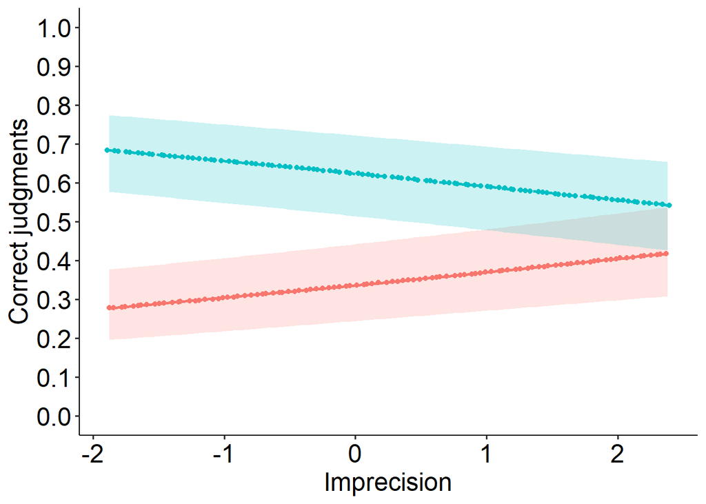

[figure not shown]

Plots for Polarization:

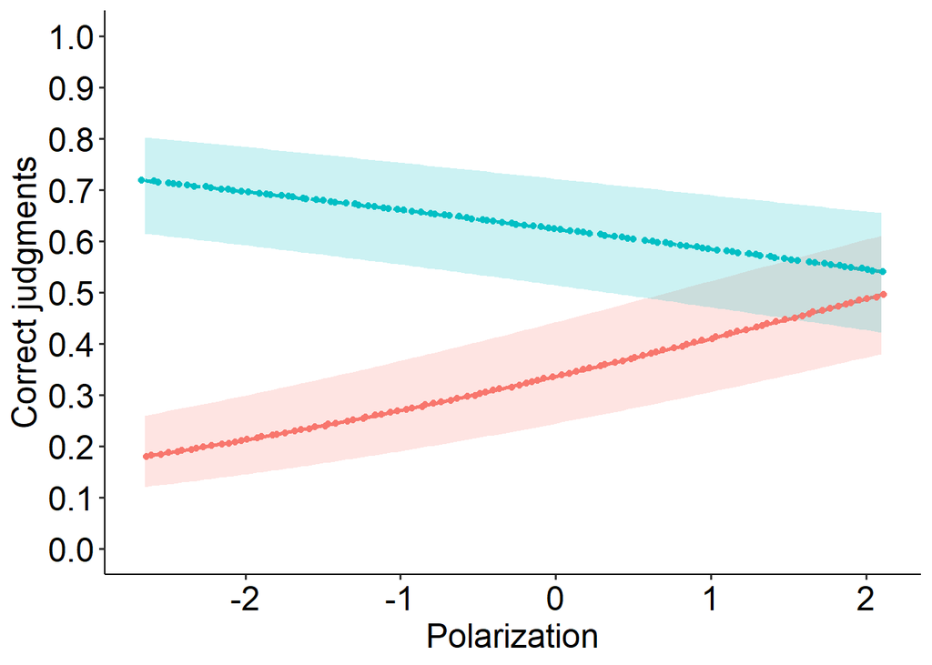

[figure not shown]

Finally, we combine plots:

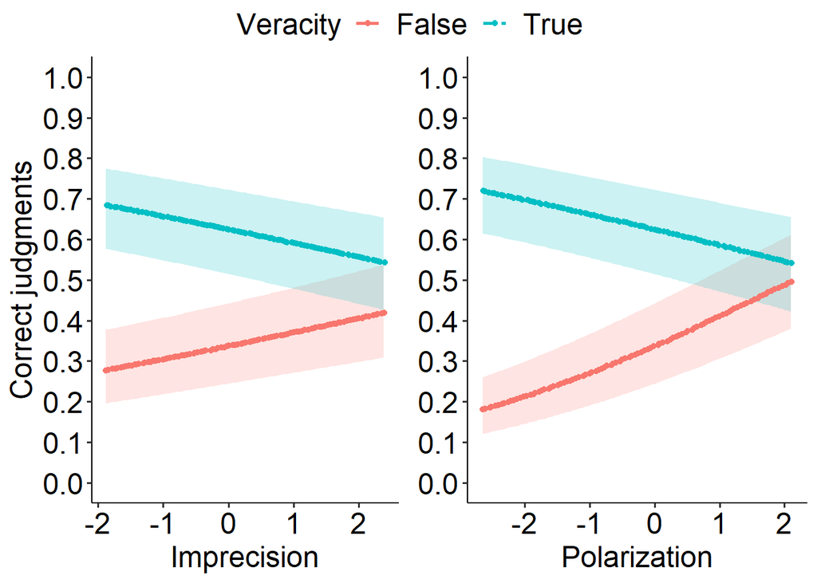

## E. MLM of judgment: interaction effect of imprecision with veracity

We test models of judgment as explained by the level of news content imprecision:

|  | Judgment |  |  | Judgment |  |  | Judgment |  |  |
| --- | --- | --- | --- | --- | --- | --- | --- | --- | --- |
| Predictors | Odds Ratios | CI | p | Odds Ratios | CI | p | Odds Ratios | CI | p |
| (Intercept) | 1.51 | 1.43 – 1.60 | **<0.001** | 1.36 | 1.27 – 1.45 | **<0.001** | 1.73 | 0.87 – 3.46 | 0.121 |
| Veracity: False | *Reference* |  |  | *Reference* |  |  | *Reference* |  |  |
| Veracity: True |  |  |  | 1.23 | 1.14 – 1.32 | **<0.001** | 1.78 | 1.53 – 2.07 | **<0.001** |
| Imprecision | 0.83 | 0.80 – 0.87 | **<0.001** | 0.81 | 0.77 – 0.86 | **<0.001** | 0.78 | 0.74 – 0.83 | **<0.001** |
| Polarization | 0.71 | 0.68 – 0.74 | **<0.001** | 0.66 | 0.62 – 0.69 | **<0.001** | 0.64 | 0.60 – 0.68 | **<0.001** |
| VeracityTrue:Imprecision |  |  |  | 1.02 | 0.95 – 1.10 | 0.602 | 1.07 | 0.98 – 1.16 | 0.130 |
| VeracityTrue:Polarization |  |  |  | 1.15 | 1.06 – 1.24 | **<0.001** | 1.33 | 1.22 – 1.46 | **<0.001** |
| Theme: Ecology | *Reference* |  |  | *Reference* |  |  | *Reference* |  |  |
| Theme: Social Justice |  |  |  |  |  |  | 1.25 | 1.08 – 1.45 | **0.003** |
| Theme: Democracy |  |  |  |  |  |  | 1.17 | 1.01 – 1.36 | **0.040** |
| VeracityTrue:ThemeSocial Justice |  |  |  |  |  |  | 0.74 | 0.60 – 0.91 | **0.005** |
| VeracityTrue:ThemeDemocracy |  |  |  |  |  |  | 0.45 | 0.36 – 0.56 | **<0.001** |
| Confidence |  |  |  |  |  |  | 1.02 | 0.95 – 1.10 | 0.519 |
| Age |  |  |  |  |  |  | 0.97 | 0.91 – 1.05 | 0.470 |
| Sex: Female | *Reference* |  |  | *Reference* |  |  | *Reference* |  |  |
| Sex: Male |  |  |  |  |  |  | 1.05 | 0.93 – 1.19 | 0.445 |
| Epistemic_curiosity |  |  |  |  |  |  | 0.99 | 0.93 – 1.06 | 0.847 |
| Education: Brevet | *Reference* |  |  | *Reference* |  |  | *Reference* |  |  |
| Education: Bac |  |  |  |  |  |  | 0.65 | 0.33 – 1.30 | 0.222 |
| Education: Licence |  |  |  |  |  |  | 0.63 | 0.30 – 1.31 | 0.214 |
| Education: Master |  |  |  |  |  |  | 0.74 | 0.37 – 1.49 | 0.398 |
| Random Effects |  |  |  |  |  |  |  |  |  |
| σ<sup>2</sup> | 3.29 |  |  | 3.29 |  |  | 3.29 |  |  |
| τ<sub>00</sub> | 0.13 <sub>Subject</sub> |  |  | 0.13 <sub>Subject</sub> |  |  | 0.13 <sub>Subject</sub> |  |  |
| τ<sub>11</sub> |  |  |  |  |  |  | 0.17 <sub>Subject.Confidence</sub> |  |  |
| ρ<sub>01</sub> |  |  |  |  |  |  | 0.42 <sub>Subject</sub> |  |  |
| ICC | 0.04 |  |  | 0.04 |  |  | 0.08 |  |  |
| N | 258 <sub>Subject</sub> |  |  | 258 <sub>Subject</sub> |  |  | 228 <sub>Subject</sub> |  |  |
| Observations | 12384 |  |  | 12384 |  |  | 10944 |  |  |
| Marginal R<sup>2</sup> / Conditional R<sup>2</sup> | 0.043 / 0.078 |  |  | 0.047 / 0.083 |  |  | 0.057 / 0.135 |  |  |

We compute estimated marginal means (emmeans) of judgment as explained by the model of imprecision interacting with the veracity, controlled as follows:

```
## Judgment ~ Veracity * Polarization + Veracity * Imprecision +
##     Confidence + Veracity * Theme + Age + Sex + Education + Epistemic_curiosity +
##     (1 + Confidence | Subject)
```

We run type III anova to test for the interaction effect plus main effects

| Variables | Chisq | Df | Pr(>Chisq) |
| --- | --- | --- | --- |
| (Intercept) | 2.41 | 1 | 0.121 ns |
| Veracity | 55.12 | 1 | <.001 *** |
| Polarization | 200.63 | 1 | <.001 *** |
| Imprecision | 58.03 | 1 | <.001 *** |
| Confidence | 0.42 | 1 | 0.519 ns |
| Theme | 8.95 | 2 | 0.011 ns |
| Age | 0.52 | 1 | 0.470 ns |
| Sex | 0.58 | 1 | 0.445 ns |
| Education | 4.34 | 3 | 0.227 ns |
| Epistemic_curiosity | 0.04 | 1 | 0.847 ns |
| Veracity:Polarization | 38.48 | 1 | <.001 *** |
| Veracity:Imprecision | 2.30 | 1 | 0.130 ns |
| Veracity:Theme | 52.79 | 2 | <.001 *** |

```
## [1] "C:/Users/vguigon/Desktop/Research_directory/receivingNews/outputs/figures/R/aov_rand2_mJudgment_truth_ambig2_ctrld.png"
```

The probability of veracity judgment for true and false news, given an imprecision at the lowest or highest level, is:

```
## Veracity = False:
##  Imprecision  prob     SE  df asymp.LCL asymp.UCL
##        -1.88 0.719 0.0264 Inf     0.664     0.768
##         2.38 0.475 0.0350 Inf     0.407     0.544
##
## Veracity = True:
##  Imprecision  prob     SE  df asymp.LCL asymp.UCL
##        -1.88 0.720 0.0266 Inf     0.665     0.769
##         2.38 0.546 0.0333 Inf     0.481     0.610
##
## Results are averaged over the levels of: Polarization, Confidence, Theme, Age, Sex, Education, Epistemic_curiosity
## Confidence level used: 0.95
## Intervals are back-transformed from the logit scale
```

As content imprecision increased, the likelihood to judge news as true significantly decreased:

```
## Veracity = False:
##  Imprecision_pairwise                   odds.ratio    SE  df null z.ratio p.value
##  (-1.87817098663269) / 2.38000040419844       2.83 0.386 Inf    1   7.618  <.0001
##
## Veracity = True:
##  Imprecision_pairwise                   odds.ratio    SE  df null z.ratio p.value
##  (-1.87817098663269) / 2.38000040419844       2.13 0.269 Inf    1   6.022  <.0001
##
## Results are averaged over the levels of: Polarization, Confidence, Theme, Age, Sex, Education, Epistemic_curiosity
## Tests are performed on the log odds ratio scale
```

Imprecision plots:

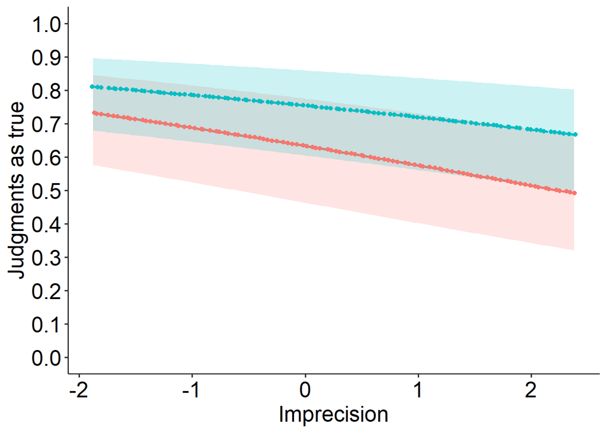

[figure not shown]

Polarization plots:

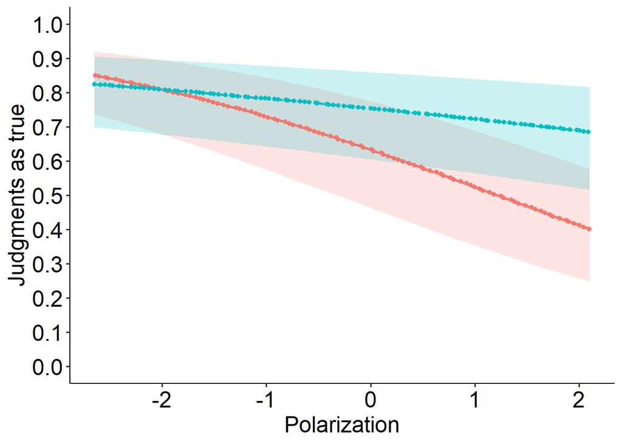

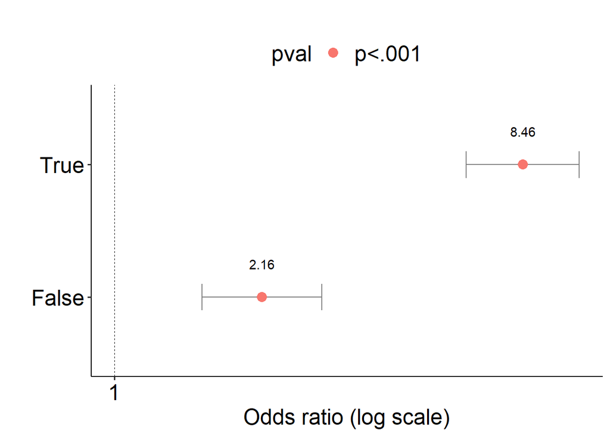

Finally, we combine plots:

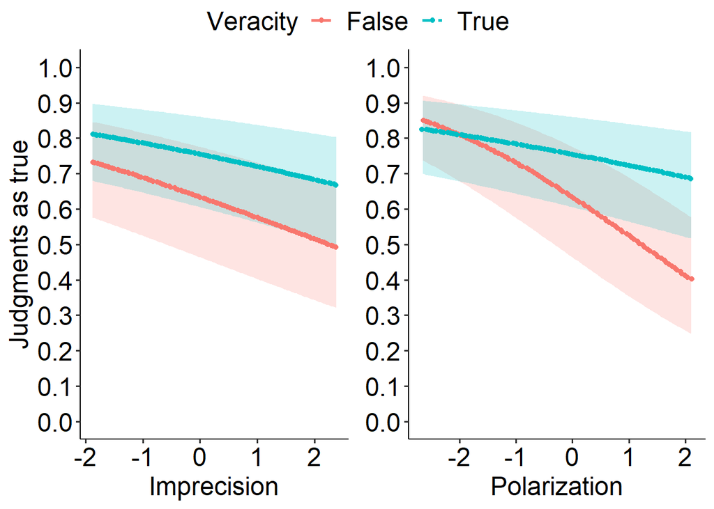

## F. MLM of success: Alternative hypotheses

We test alternative hypotheses for the success in estimating veracity:

RT models:

|  | Success |  |  | Success |  |  |
| --- | --- | --- | --- | --- | --- | --- |
| Predictors | Odds Ratios | CI | p | Odds Ratios | CI | p |
| (Intercept) | 1.06 | 1.03 – 1.10 | **0.001** | 0.40 | 0.26 – 0.61 | **<0.001** |
| Estimation_RT | 1.07 | 1.02 – 1.12 | **0.007** | 1.04 | 0.99 – 1.09 | 0.155 |
| Confidence |  |  |  | 1.03 | 0.99 – 1.08 | 0.142 |
| Veracity: False | *Reference* |  |  | *Reference* |  |  |
| Veracity: True |  |  |  | 4.30 | 3.74 – 4.94 | **<0.001** |
| Theme: Ecology | *Reference* |  |  | *Reference* |  |  |
| Theme: Social Justice |  |  |  | 1.25 | 1.09 – 1.43 | **0.001** |
| Theme: Democracy |  |  |  | 1.38 | 1.20 – 1.57 | **<0.001** |
| VeracityTrue:ThemeDemocracy |  |  |  | 0.38 | 0.32 – 0.46 | **<0.001** |
| Education: Master |  |  |  | 1.31 | 0.85 – 2.02 | 0.229 |
| Age |  |  |  | 0.99 | 0.95 – 1.04 | 0.806 |
| Sex: Female | *Reference* |  |  | *Reference* |  |  |
| Sex: Male |  |  |  | 1.06 | 0.97 – 1.15 | 0.179 |
| Epistemic_curiosity |  |  |  | 1.02 | 0.98 – 1.06 | 0.358 |
| Education: Brevet | *Reference* |  |  | *Reference* |  |  |
| Education: Bac |  |  |  | 1.33 | 0.87 – 2.04 | 0.193 |
| Education: Licence |  |  |  | 1.26 | 0.79 – 2.01 | 0.333 |
| VeracityTrue:ThemeSocial Justice |  |  |  | 0.73 | 0.60 – 0.88 | **0.001** |
| Random Effects |  |  |  |  |  |  |
| σ<sup>2</sup> | 3.29 |  |  | 3.29 |  |  |
| τ<sub>00</sub> | 0.00 <sub>Subject</sub> |  |  | 0.00 <sub>Subject</sub> |  |  |
| τ<sub>11</sub> | 0.00 <sub>Subject.Estimation_RT</sub> |  |  | 0.01 <sub>Subject.Estimation_RT</sub> |  |  |
|  |  |  |  | 0.01 <sub>Subject.Confidence</sub> |  |  |
| ρ<sub>01</sub> |  |  |  |  |  |  |
| N | 258 <sub>Subject</sub> |  |  | 228 <sub>Subject</sub> |  |  |
| Observations | 12384 |  |  | 10944 |  |  |
| Marginal R<sup>2</sup> / Conditional R<sup>2</sup> | 0.001 / NA |  |  | 0.089 / NA |  |  |

Confidence models:

|  | Success |  |  | Success |  |  |
| --- | --- | --- | --- | --- | --- | --- |
| Predictors | Odds Ratios | CI | p | Odds Ratios | CI | p |
| (Intercept) | 1.06 | 1.03 – 1.10 | **0.001** | 0.58 | 0.52 – 0.64 | **<0.001** |
| Confidence | 1.06 | 1.02 – 1.10 | **0.005** | 1.09 | 1.02 – 1.15 | **0.007** |
| Judgment: False | *Reference* |  |  | *Reference* |  |  |
| Judgment: True |  |  |  | 0.90 | 0.83 – 0.97 | **0.004** |
| JudgmentTrue:Confidence |  |  |  | 0.95 | 0.88 – 1.02 | 0.154 |
| Veracity: False | *Reference* |  |  | *Reference* |  |  |
| Veracity: True |  |  |  | 4.22 | 3.70 – 4.81 | **<0.001** |
| Theme: Ecology | *Reference* |  |  | *Reference* |  |  |
| Theme: Social Justice |  |  |  | 1.22 | 1.08 – 1.39 | **0.002** |
| Theme: Democracy |  |  |  | 1.33 | 1.17 – 1.51 | **<0.001** |
| VeracityTrue:ThemeSocial Justice |  |  |  | 0.75 | 0.62 – 0.90 | **0.002** |
| VeracityTrue:ThemeDemocracy |  |  |  | 0.41 | 0.34 – 0.49 | **<0.001** |
| Random Effects |  |  |  |  |  |  |
| σ<sup>2</sup> | 3.29 |  |  | 3.29 |  |  |
| τ<sub>00</sub> | 0.00 <sub>Subject</sub> |  |  | 0.00 <sub>Subject</sub> |  |  |
| τ<sub>11</sub> | 0.01 <sub>Subject.Confidence</sub> |  |  | 0.00 <sub>Subject.JudgmentTrue</sub> |  |  |
|  |  |  |  | 0.01 <sub>Subject.Confidence</sub> |  |  |
| ρ<sub>01</sub> | -1.00 <sub>Subject</sub> |  |  | -0.94 |  |  |
|  |  |  |  | 0.56 |  |  |
| ICC | 0.00 |  |  | 0.00 |  |  |
| N | 258 <sub>Subject</sub> |  |  | 258 <sub>Subject</sub> |  |  |
| Observations | 12384 |  |  | 12384 |  |  |
| Marginal R<sup>2</sup> / Conditional R<sup>2</sup> | 0.001 / 0.004 |  |  | 0.088 / 0.092 |  |  |

Organizations models:

|  | Ecology_success |  |  | Democracy_success |  |  | SocJust_success |  |  |
| --- | --- | --- | --- | --- | --- | --- | --- | --- | --- |
| Predictors | Odds Ratios | CI | p | Odds Ratios | CI | p | Odds Ratios | CI | p |
| (Intercept) | 0.91 | 0.59 – 1.40 | 0.662 | 0.98 | 0.72 – 1.33 | 0.907 | 1.27 | 0.87 – 1.88 | 0.218 |
| Climato_realistes | 1.00 | 1.00 – 1.00 | 0.925 |  |  |  |  |  |  |
| Greenpeace | 1.00 | 0.99 – 1.00 | 0.686 |  |  |  |  |  |  |
| NIPCC | 1.00 | 1.00 – 1.00 | 0.549 |  |  |  |  |  |  |
| WWF | 1.00 | 1.00 – 1.01 | 0.372 |  |  |  |  |  |  |
| Fondation_Robert_Schuman |  |  |  | 1.00 | 1.00 – 1.01 | 0.760 |  |  |  |
| Frexit |  |  |  | 1.00 | 1.00 – 1.00 | 0.840 |  |  |  |
| Mouvement_europeen_france |  |  |  | 1.00 | 0.99 – 1.00 | 0.690 |  |  |  |
| Parti_libertarien |  |  |  | 1.00 | 1.00 – 1.00 | 0.634 |  |  |  |
| Femen |  |  |  |  |  |  | 1.00 | 1.00 – 1.01 | 0.151 |
| Generation_identitaire |  |  |  |  |  |  | 1.00 | 0.99 – 1.00 | 0.084 |
| La_manif_pour_tous |  |  |  |  |  |  | 1.00 | 1.00 – 1.00 | 0.557 |
| Sos_mediterranee |  |  |  |  |  |  | 1.00 | 1.00 – 1.00 | 0.805 |
| Random Effects |  |  |  |  |  |  |  |  |  |
| σ<sup>2</sup> | 3.29 |  |  | 3.29 |  |  | 3.29 |  |  |
| τ<sub>00</sub> | 0.00 <sub>Subject</sub> |  |  | 0.00 <sub>Subject</sub> |  |  | 0.00 <sub>Subject</sub> |  |  |
| N | 258 <sub>Subject</sub> |  |  | 258 <sub>Subject</sub> |  |  | 258 <sub>Subject</sub> |  |  |
| Observations | 4128 |  |  | 4128 |  |  | 4128 |  |  |
| Marginal R<sup>2</sup> / Conditional R<sup>2</sup> | 0.000 / NA |  |  | 0.000 / NA |  |  | 0.002 / NA |  |  |

Alternatives models:

|  | Success |  |  | Success |  |  | Success |  |  | Success |  |  |
| --- | --- | --- | --- | --- | --- | --- | --- | --- | --- | --- | --- | --- |
| Predictors | Odds Ratios | CI | p | Odds Ratios | CI | p | Odds Ratios | CI | p | Odds Ratios | CI | p |
| (Intercept) | 1.06 | 1.03 – 1.10 | **0.001** | 0.54 | 0.50 – 0.59 | **<0.001** | 0.80 | 0.53 – 1.20 | 0.272 | 1.09 | 0.95 – 1.26 | 0.212 |
| Estimation_RT | 1.07 | 1.02 – 1.12 | **0.007** | 1.05 | 1.01 – 1.10 | **0.030** |  |  |  |  |  |  |
| Veracity: False | *Reference* |  |  | *Reference* |  |  | *Reference* |  |  | *Reference* |  |  |
| Veracity: True |  |  |  | 4.16 | 3.66 – 4.74 | **<0.001** |  |  |  |  |  |  |
| Theme: Ecology | *Reference* |  |  | *Reference* |  |  | *Reference* |  |  | *Reference* |  |  |
| Theme: Social Justice |  |  |  | 1.24 | 1.09 – 1.41 | **0.001** |  |  |  |  |  |  |
| Theme: Democracy |  |  |  | 1.33 | 1.17 – 1.51 | **<0.001** |  |  |  |  |  |  |
| VeracityTrue:ThemeSocial Justice |  |  |  | 0.74 | 0.62 – 0.89 | **0.001** |  |  |  |  |  |  |
| VeracityTrue:ThemeDemocracy |  |  |  | 0.41 | 0.34 – 0.49 | **<0.001** |  |  |  |  |  |  |
| Age |  |  |  |  |  |  | 0.99 | 0.95 – 1.03 | 0.559 |  |  |  |
| Sex: Female | *Reference* |  |  | *Reference* |  |  | *Reference* |  |  | *Reference* |  |  |
| Sex: Male |  |  |  |  |  |  | 1.06 | 0.98 – 1.14 | 0.122 |  |  |  |
| Epistemic_curiosity |  |  |  |  |  |  | 1.02 | 0.98 – 1.06 | 0.313 |  |  |  |
| Education: Brevet | *Reference* |  |  | *Reference* |  |  | *Reference* |  |  | *Reference* |  |  |
| Education: Bac |  |  |  |  |  |  | 1.31 | 0.87 – 1.97 | 0.189 |  |  |  |
| Education: Licence |  |  |  |  |  |  | 1.23 | 0.79 – 1.92 | 0.361 |  |  |  |
| Education: Master |  |  |  |  |  |  | 1.30 | 0.86 – 1.97 | 0.209 |  |  |  |
| Distrust_environmental_activists |  |  |  |  |  |  |  |  |  | 1.00 | 1.00 – 1.00 | 0.167 |
| Distrust_general |  |  |  |  |  |  |  |  |  | 1.00 | 1.00 – 1.00 | 0.542 |
| Distrust_journalists |  |  |  |  |  |  |  |  |  | 1.00 | 1.00 – 1.00 | 0.543 |
| Distrust_physicians |  |  |  |  |  |  |  |  |  | 1.00 | 1.00 – 1.00 | 0.845 |
| Distrust_politics |  |  |  |  |  |  |  |  |  | 1.00 | 1.00 – 1.00 | 0.892 |
| Distrust_researchers |  |  |  |  |  |  |  |  |  | 1.00 | 1.00 – 1.00 | **0.045** |
| Distrust_socjust_activists |  |  |  |  |  |  |  |  |  | 1.00 | 1.00 – 1.00 | 0.830 |
| Random Effects |  |  |  |  |  |  |  |  |  |  |  |  |
| σ<sup>2</sup> | 3.29 |  |  | 3.29 |  |  | 3.29 |  |  | 3.29 |  |  |
| τ<sub>00</sub> | 0.00 <sub>Subject</sub> |  |  | 0.00 <sub>Subject</sub> |  |  | 0.00 <sub>Subject</sub> |  |  | 0.00 <sub>Subject</sub> |  |  |
|  |  |  |  |  |  |  |  |  |  | 0.01 <sub>Order</sub> |  |  |
|  |  |  |  |  |  |  |  |  |  | 0.00 <sub>Group</sub> |  |  |
| τ<sub>11</sub> | 0.00 <sub>Subject.Estimation_RT</sub> |  |  | 0.01 <sub>Subject.Estimation_RT</sub> |  |  |  |  |  |  |  |  |
| ρ<sub>01</sub> |  |  |  |  |  |  |  |  |  |  |  |  |
| ICC |  |  |  |  |  |  |  |  |  | 0.00 |  |  |
| N | 258 <sub>Subject</sub> |  |  | 258 <sub>Subject</sub> |  |  | 228 <sub>Subject</sub> |  |  | 179 <sub>Subject</sub> |  |  |
|  |  |  |  |  |  |  |  |  |  | 48 <sub>Order</sub> |  |  |
|  |  |  |  |  |  |  |  |  |  | 2 <sub>Group</sub> |  |  |
| Observations | 12384 |  |  | 12384 |  |  | 10944 |  |  | 8592 |  |  |
| Marginal R<sup>2</sup> / Conditional R<sup>2</sup> | 0.001 / NA |  |  | 0.086 / NA |  |  | 0.001 / NA |  |  | 0.001 / 0.003 |  |  |

## G. MLM of judgment: Alternative hypotheses

We test the alternative hypotheses for the judgment of veracity:

|  | Judgment |  |  | Judgment |  |  |
| --- | --- | --- | --- | --- | --- | --- |
| Predictors | Odds Ratios | CI | p | Odds Ratios | CI | p |
| (Intercept) | 1.62 | 1.46 – 1.80 | **<0.001** | 1.63 | 1.47 – 1.80 | **<0.001** |
| Confidence | 1.04 | 0.97 – 1.11 | 0.237 | 1.04 | 0.98 – 1.11 | 0.210 |
| Estimation_RT | 0.85 | 0.80 – 0.91 | **<0.001** |  |  |  |
| Veracity: False | *Reference* |  |  | *Reference* |  |  |
| Veracity: True | 1.38 | 1.21 – 1.58 | **<0.001** | 1.38 | 1.21 – 1.57 | **<0.001** |
| Theme: Ecology | *Reference* |  |  | *Reference* |  |  |
| Theme: Social Justice | 0.85 | 0.74 – 0.96 | **0.011** | 0.85 | 0.75 – 0.97 | **0.013** |
| Theme: Democracy | 0.82 | 0.72 – 0.93 | **0.002** | 0.82 | 0.72 – 0.93 | **0.002** |
| VeracityTrue:ThemeSocial Justice | 0.99 | 0.82 – 1.19 | 0.917 | 0.98 | 0.81 – 1.18 | 0.830 |
| VeracityTrue:ThemeDemocracy | 0.57 | 0.47 – 0.68 | **<0.001** | 0.56 | 0.47 – 0.68 | **<0.001** |
| Random Effects |  |  |  |  |  |  |
| σ<sup>2</sup> | 3.29 |  |  | 3.29 |  |  |
| τ<sub>00</sub> | 0.13 <sub>Subject</sub> |  |  | 0.13 <sub>Subject</sub> |  |  |
| τ<sub>11</sub> | 0.03 <sub>Subject.Estimation_RT</sub> |  |  | 0.16 <sub>Subject.Confidence</sub> |  |  |
|  | 0.16 <sub>Subject.Confidence</sub> |  |  |  |  |  |
| ρ<sub>01</sub> | -0.37 |  |  | 0.49 <sub>Subject</sub> |  |  |
|  | 0.48 |  |  |  |  |  |
| ICC | 0.09 |  |  | 0.08 |  |  |
| N | 258 <sub>Subject</sub> |  |  | 258 <sub>Subject</sub> |  |  |
| Observations | 12384 |  |  | 12384 |  |  |
| Marginal R<sup>2</sup> / Conditional R<sup>2</sup> | 0.024 / 0.112 |  |  | 0.018 / 0.095 |  |  |